# Decomposition Techniques for Social Epidemiology: Why and How

## Example: Decomposing Socioeconomic Inequality in Current Smoking

## Data: European Social Survey Round 11 for Sweden

Unique

Missing Pct.

Mean

SD

Min

Median

Max

Histogram

Current smoker

2

0

0.1

0.2

0.0

0.0

1.0

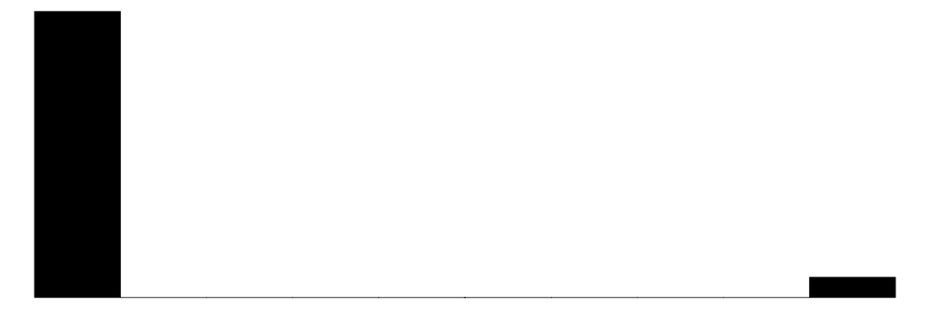

Income decile

10

0

6.6

2.6

1.0

7.0

10.0

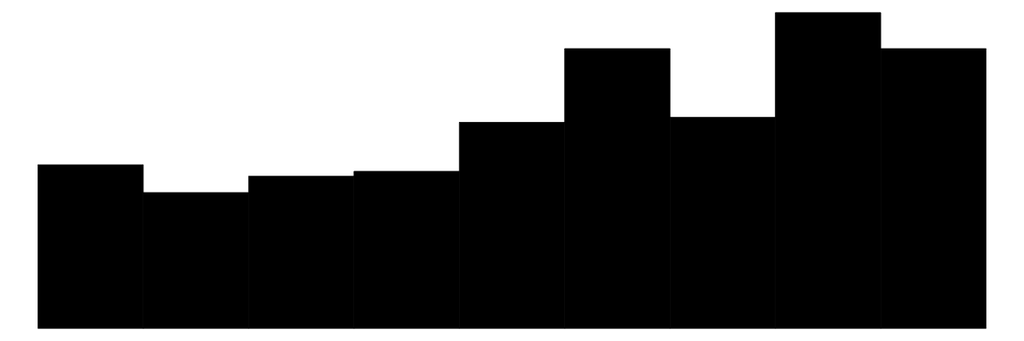

Age (years)

76

0

54.4

18.6

15.0

56.0

90.0

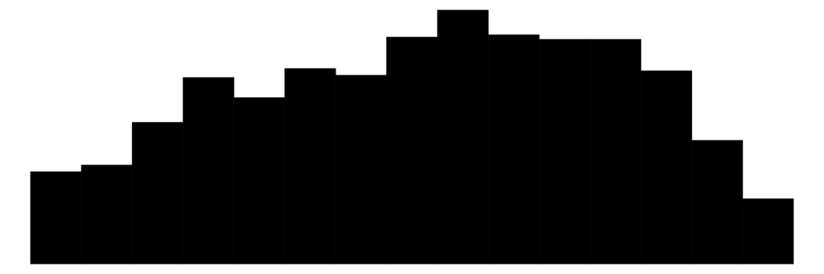

Low education (ISCED 1–4)

2

0

0.4

0.5

0.0

0.0

1.0

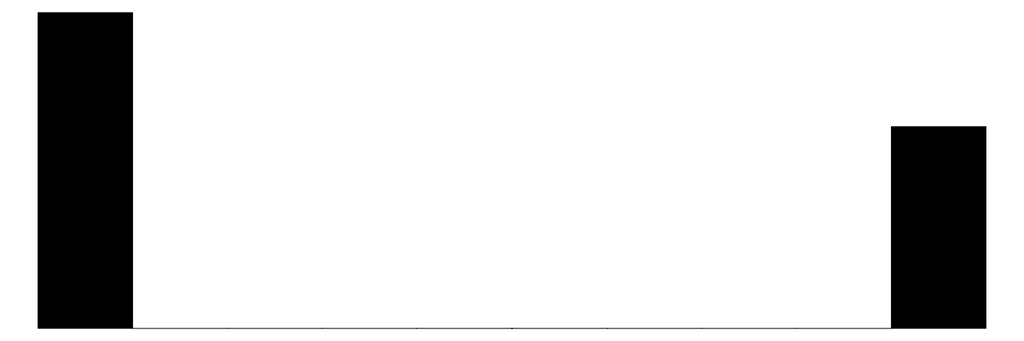

Female

2

0

0.5

0.5

0.0

0.0

1.0

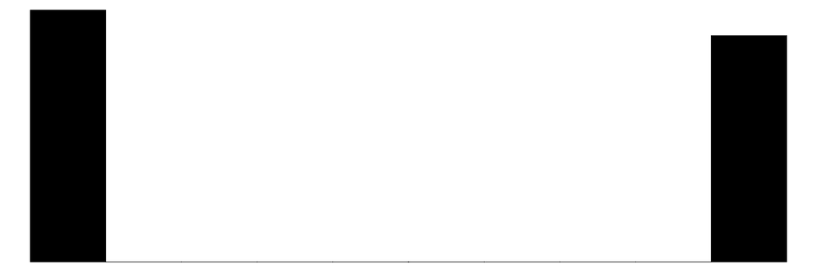

Binge drinking (monthly+)

2

0

0.5

0.5

0.0

0.0

1.0

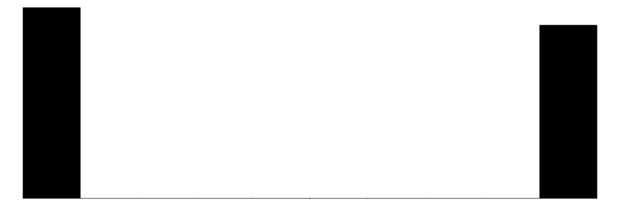

Obese (BMI ≥ 30)

2

0

0.1

0.4

0.0

0.0

1.0

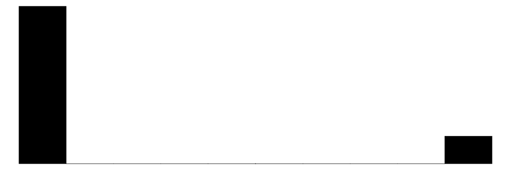

Married

2

0

0.5

0.5

0.0

0.0

1.0

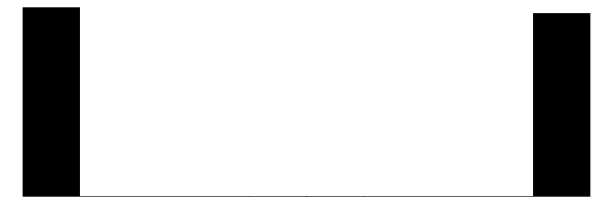

Survey weight

132

0

1.0

0.5

0.3

0.8

4.0

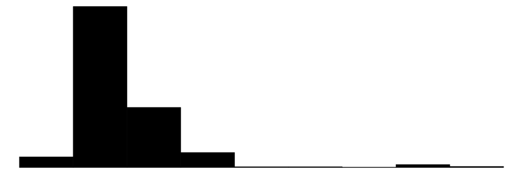

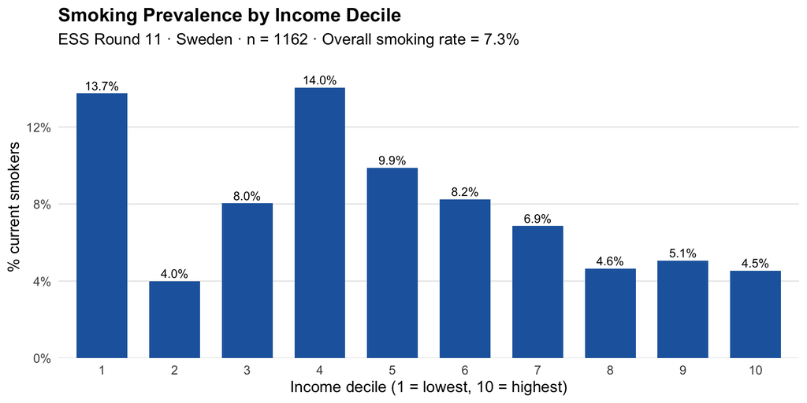

Source: Author’s calculations

### What are we explaining?

Overall CI = -0.20

Smoking *more concentrated* among the poor

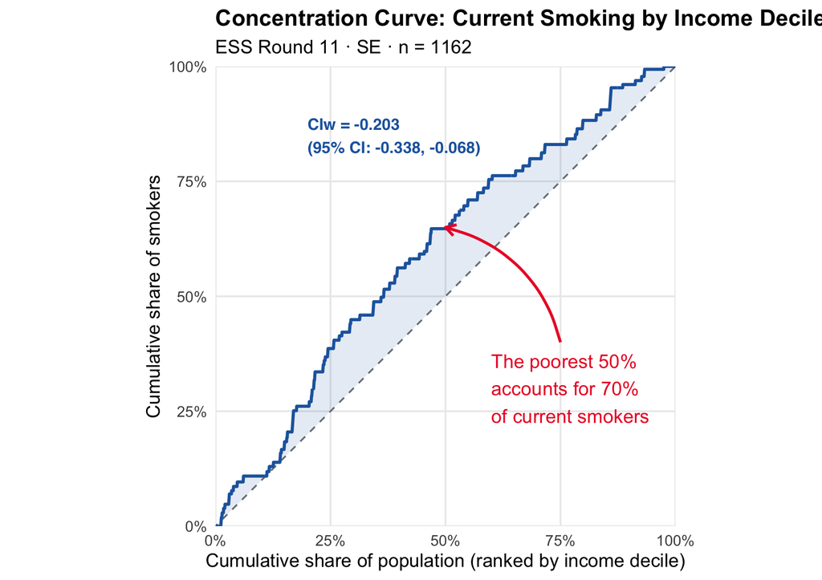

## Step 1: Predictors of current smoking

| Variable | β | OR | 95% CI | p |
| --- | --- | --- | --- | --- |
| Age (years) | -0.001 | 0.999 | (0.99, 1.01) | 0.906 |
| Female | 0.141 | 1.152 | (0.73, 1.83) | 0.547 |
| Low education (ISCED 1–4) | 0.359 | 1.432 | (0.90, 2.27) | 0.130 |
| Married | -0.989 | 0.372 | (0.21, 0.65) | <0.001 |
| Binge drinking (monthly+) | 0.38 | 1.463 | (0.92, 2.32) | 0.107 |
| Obese (BMI ≥ 30) | 0.495 | 1.64 | (0.90, 2.99) | 0.106 |

## Step 2: Estimating elasticity for low education

$$RCI=\sum{ \underbrace{(\beta_{k}\bar{x}_{k}/\mu)}_{\text{elasticity}} RCI_{k}}+gRCI_{e}/\mu$$

- $\beta_{\text{low education}}$ = 0.36 (OR = 1.4)
- Marginal effect: 0.024
- Mean low education: 0.452
- Mean smoking rate: 7.3%

Elasticity for low education is: (0.024 * 0.452 / .073) = 0.148

What about the RCI for low education?

This is Step (2): Calculate the mean of $y$ $(\mu)$ and of each of the $x_{k}$ determinants

Step 3: $RCI_{k}$

Note the y-axis is cumulative share of *low education*

The poorest 50% account for roughly 60% of the share of low educated.

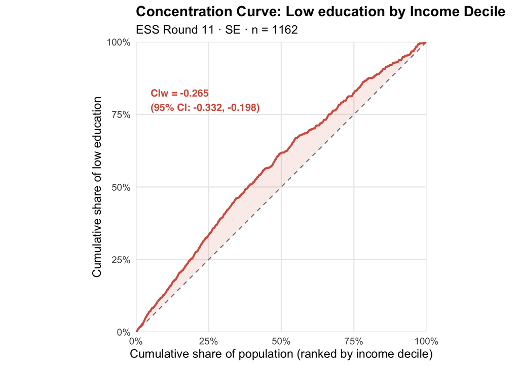

This is Step (3): Calculate the $CI$ for each of the potential determinants $x_{k}$

## Step 4: Calculate contributions

Estimation for a specific factor: Low education

$$RCI=\sum{ \underbrace{(\beta_{k}\bar{x}_{k}/\mu)}_{\text{elasticity}} RCI_{k}}+gRCI_{e}/\mu$$

The elasticity of smoking (prior slide) = 0.148

Now we have $RCI_{k}$ for low education = -0.265

The contribution of low education:

$$\text{Elasticity}\times RCI_{ed} = 0.148 * -0.265 = -.039$$

**Thus low education accounts for -.039/ -0.203 = 19% of the overall** $RCI$

RCI = -0.203

(-) Binge drinking: ↑ smoking but more common at higher incomes

(+) Married: ↓ smoking but more common at higher incomes

| Variable | Elasticity | CI_k | Contribution Absolute | Contribution % |
| --- | --- | --- | --- | --- |
| Age | -0.030 | 0.001 | -0.000 | 0.0 |
| Binge drinker | 0.152 | 0.103 | 0.016 | -7.7 |
| Female | 0.060 | -0.031 | -0.002 | 0.9 |
| Obese | 0.068 | -0.013 | -0.001 | 0.4 |
| Low education | 0.144 | -0.265 | -0.038 | 18.8 |
| Married | -0.353 | 0.284 | -0.100 | 49.4 |
| Residual | — | — | -0.077 | 38.1 |

Logistic regression; marginal effects used as elasticity weights.

## Uncertainty in the RCI Decomposition

Each contribution has sampling variability:

$$\underbrace{\frac{\hat{\beta}_k \bar{x}_k}{\hat{\mu}}}_{\text{elasticity}} \times \underbrace{\widehat{RCI}_k}_{\text{inequality in }x_k}$$

Can **bootstrap** the decomp $B$ times to get empirical CIs.

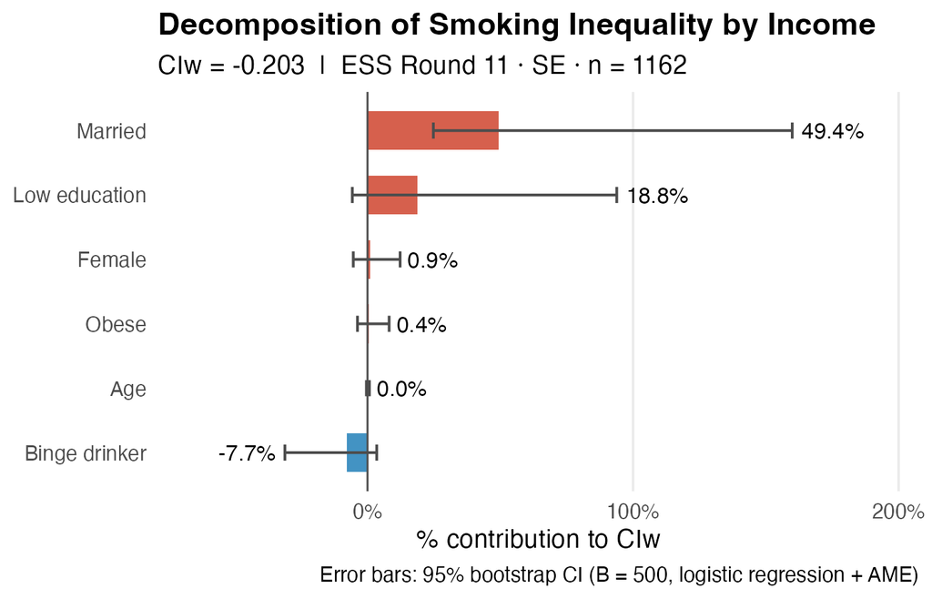

See O’Donnell et al. (2008); Hosseinpoor, Doorslaer, and Speybroeck (2006)

## Summary: Concentration index decomposition

**When to use**  
Summarizing with RCI and asking which determinants drive it

**Extensions**  
Nonlinear models; Oaxaca-type decomposition of differences and temporal changes

**Caveats**  
‘Explained’ share depends on well-specified model; predictive, not causal

Wagstaff, Doorslaer, and Watanabe (2003); Kakwani, Wagstaff, and Doorslaer (1997); O’Donnell et al. (2008); Erreygers and Kessels (2016)

## Covered Today

**1. Kitagawa’s Decomposition**

**2. Oaxaca–Blinder Decomposition**

**3. Concentration Index Decomposition**

**4. Interventional Decomposition**

# 4. Interventional Decomposition

## Origins: Why ‘interventional’?

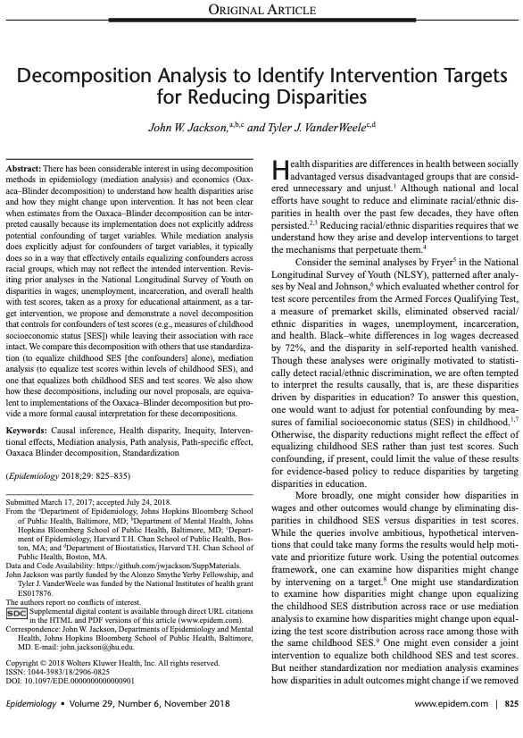

Prior decompositions (e.g., Kitagawa, O-B) ‘descriptive’

Causal mediation challenges

Challenges with non-manipulable exposures

**How much would gaps change if we intervened on a target?**

Jackson and VanderWeele (2018)

## Many recent developments

Reconciling the descriptive framework of KBO with causal inference.

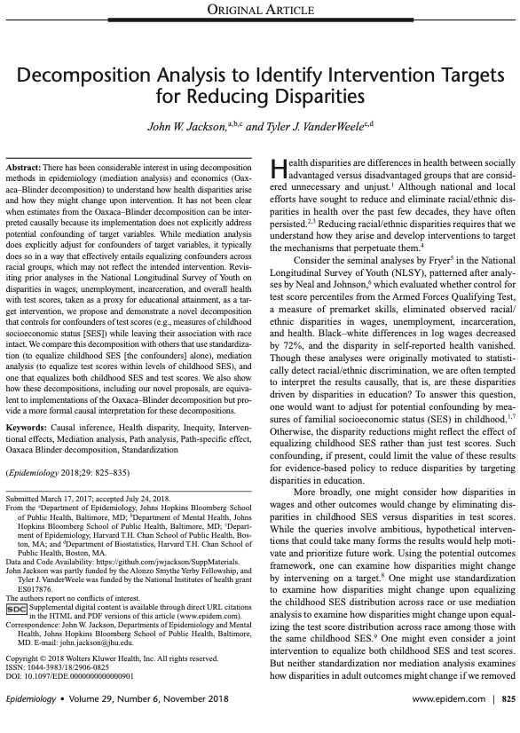

[figure not shown]

[figure not shown]

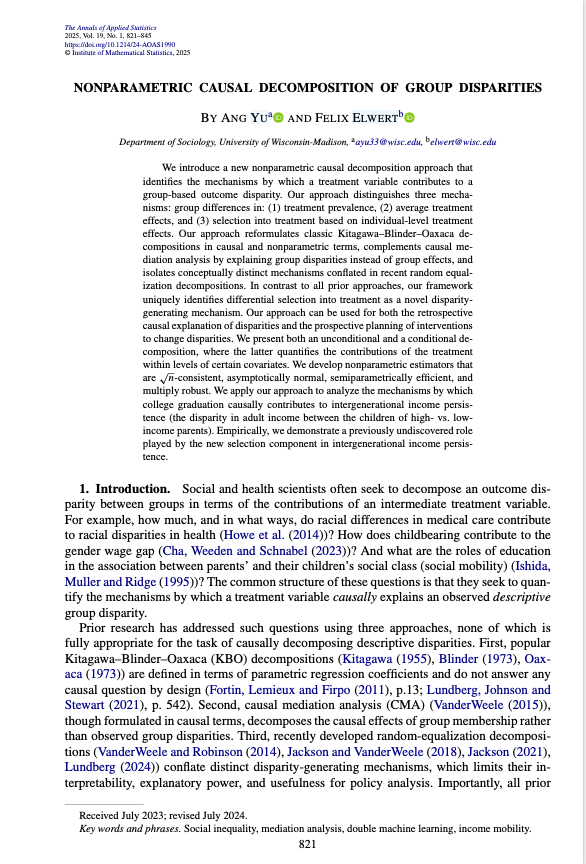

[figure not shown]

[figure not shown]

See Jackson and VanderWeele (2018); Jackson (2021); Lundberg (2024); Yu and Elwert (2025); Jackson et al. (2025); Opacic, Wei, and Zhou (2026)

## Youth accident deaths: what would we intervene on?

Danish-origin adolescents die in accidents more often than immigrant-origin peers (IRR 1.7 vs first-generation)

Alcohol is a plausible pathway: 16% of fatal accidents; Danish-origin youth have 4x the odds of an alcohol-related death

But immigrant-origin families are poorer, so adjusting for income *widens* the gap (IRR 1.7 → 2.6)

[figure not shown]

[figure not shown]

**What if** Danish-origin youth drank like their immigrant-origin peers?

Udesen et al. (2023); Kruckow and Tolstrup (2024) (ethnic IRRs inverted from Kruckow supplementary table 2)

## Conceptualizing the DAG (assumptions)

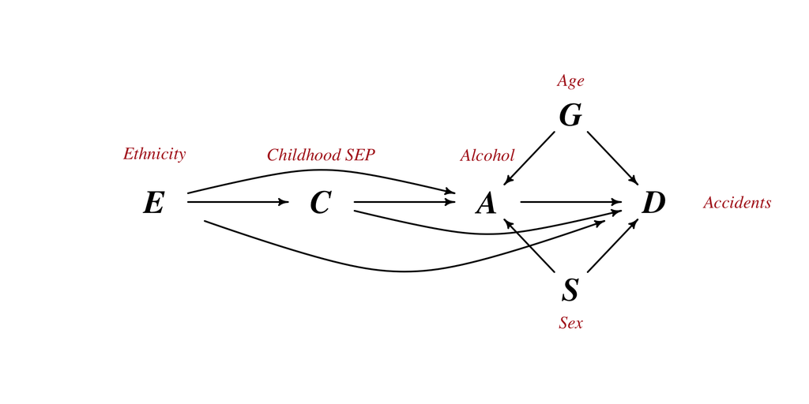

## Different from causal mediation (still valid)

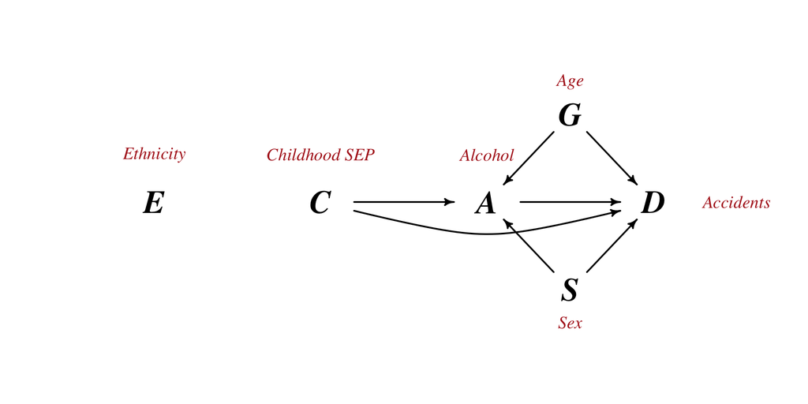

Steps for pursuing interventional decomposition

**1 Define the gap and intervention**  
Consider feasibility, implementation

**2 Draw the DAG**  
Which covariates to adjust for (allowability)

**3 Defend the assumptions**  
Exchangeability; positivity; consistency

**4 Estimate the model**  
Outcome model, weighting, doubly robust

**5 Compare factual and counterfactual**  
Consider effect scale, uncertainty

Jackson and VanderWeele (2018); Jackson (2021); Lundberg (2024)

## Recent example

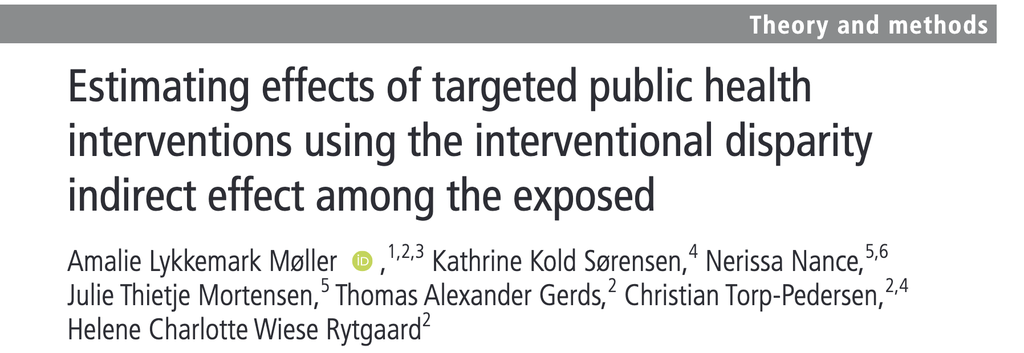

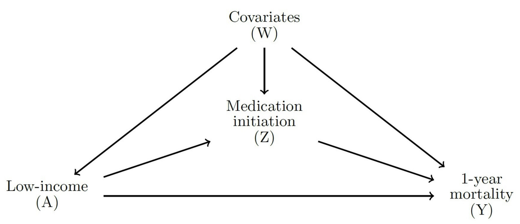

> we estimate the expected 1-year mortality among the low-income patients in a hypothetical world where they initiated medication as often as high-income patients…

Møller et al. (2026)

## Møller results

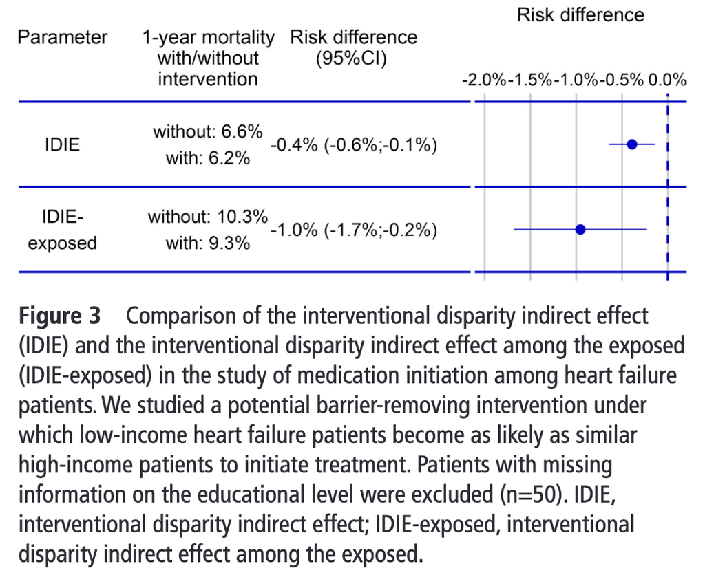

> IDIE-exposed is the expected reduction in 1-year mortality among low-income heart failure patients in a hypothetical world where they initiated medication with the same probability as observed among similar high-income patients, rather than their observed probability.

Møller et al. (2026)

## Summary: Interventional decomposition

**When to use**  
Counterfactual inequality under a hypothetical intervention on a mediator

**Extensions**  
Stochastic interventions; weighting framework; nonparametric estimation

**Caveats**  
Causal assumptions; well-defined intervention; choices about ‘allowable’ covariates

Jackson and VanderWeele (2018); Jackson (2021); Lundberg (2024); Yu and Elwert (2025); Møller et al. (2026)

## Summary

Various decomposition techniques exist that may be useful for analyzing social inequalities in health

Moves beyond measuring to explanations and interventions

Used responsibly, they can help to provide key evidence on why health inequalities exist and change over time.

## References

Blinder, Alan S. 1973. “Wage Discrimination: Reduced Form and Structural Estimates.” *Journal of Human Resources* 8 (4): 436–55. https://doi.org/10.2307/144855.

Cotton, Jeremiah. 1988. “On the Decomposition of Wage Differentials.” *The Review of Economics and Statistics* 70 (2): 236. https://doi.org/10.2307/1928307.

Das Gupta, Prithwis. 1993. “Standardization and Decomposition of Rates: A User’s Manual.” Current Population Reports P23-186. Washington, DC: U.S. Bureau of the Census.

Eikemo, Terje A., and Emil Øversveen. 2019. “Social Inequalities in Health: Challenges, Knowledge Gaps, Key Debates and the Need for New Data.” *Scandinavian Journal of Public Health* 47 (6): 593–97. https://doi.org/10.1177/1403494819866416.

Erreygers, Guido, and Roselinde Kessels. 2016. “Structural Equation Modeling for Decomposing Rank-Dependent Indicators of Socioeconomic Inequality of Health: An Empirical Study.” *Health Economics Review* 6 (1). https://doi.org/10.1186/s13561-016-0134-2.

Heller, Richard F., Patrick McElduff, and Richard Edwards. 2002. “Impact of Upward Social Mobility on Population Mortality: Analysis with Routine Data.” *BMJ* 325 (7356): 134. https://doi.org/10.1136/bmj.325.7356.134.

Hosseinpoor, Ahmad Reza, Eddy van Doorslaer, and Niko Speybroeck. 2006. “Decomposing Socioeconomic Inequality in Infant Mortality in Iran.” *International Journal of Epidemiology* 35 (5): 1211–19. https://doi.org/10.1093/ije/dyl164.

Jackson, John W. 2021. “Meaningful Causal Decompositions in Health Equity Research: Definition, Identification, and Estimation Through a Weighting Framework.” *Epidemiology* 32 (2): 282290. https://doi.org/10.1097/EDE.0000000000001319.

Jackson, John W., Yea-Jen Hsu, Raquel C. Greer, Romsai T. Boonyasai, and Chanelle J. Howe. 2025. “The Target Study: A Conceptual Model and Framework for Measuring Disparity.” *Sociological Methods & Research*, April, 00491241251314037. https://doi.org/10.1177/00491241251314037.

Jackson, John W., and Tyler J. VanderWeele. 2018. “Decomposition Analysis to Identify Intervention Targets for Reducing Disparities.” *Epidemiology* 29 (6): 825–35. https://doi.org/10.1097/EDE.0000000000000901.

Jiménez-Rubio, Dolores, and Cristina Hernández-Quevedo. 2010. “Inequalities in the Use of Health Services Between Immigrants and the Native Population in Spain: What Is Driving the Differences?” *The European Journal of Health Economics* 12 (1): 17–28. https://doi.org/10.1007/s10198-010-0220-z.

Kakwani, Nanak, Adam Wagstaff, and Eddy van Doorslaer. 1997. “Socioeconomic Inequalities in Health: Measurement, Computation, and Statistical Inference.” *Journal of Econometrics* 77 (1): 87–103. https://doi.org/10.1016/S0304-4076(96)01807-6.

Kessels, Roselinde, and Guido Erreygers. 2013. “Regression-Based Decompositions of Rank-Dependent Indicators of Socioeconomic Inequality of Health.” In *Health and Inequality*, 227–59. Emerald Group Publishing Limited. https://doi.org/10.1108/s1049-2585(2013)0000021010.

Kitagawa, Evelyn M. 1955. “Components of a Difference Between Two Rates.” *Journal of the American Statistical Association* 50 (272): 1168–94. https://doi.org/10.2307/2281213.

Kruckow, Sofie, and Janne S. Tolstrup. 2024. “All Cause and Cause Specific Mortality in 15-24-Year-Olds in Denmark 2010 to 2022: Nationwide Study of Socioeconomic Predictors.” *BMJ Medicine* 3 (1): e000685. https://doi.org/10.1136/bmjmed-2023-000685.

Lundberg, Ian. 2024. “The Gap-Closing Estimand: A Causal Approach to Study Interventions That Close Disparities Across Social Categories.” *Sociological Methods & Research* 53 (2): 507–70. https://doi.org/10.1177/00491241211055769.

Møller, Amalie Lykkemark, Kathrine Kold Sørensen, Nerissa Nance, Julie Thietje Mortensen, Thomas Alexander Gerds, Christian Torp-Pedersen, and Helene Charlotte Wiese Rytgaard. 2026. “Estimating Effects of Targeted Public Health Interventions Using the Interventional Disparity Indirect Effect Among the Exposed.” *Journal of Epidemiology and Community Health* 80 (5): 309–15. https://doi.org/10.1136/jech-2025-224627.

O’Donnell, Owen, Eddy van Doorslaer, Adam Wagstaff, and Magnus Lindelow. 2008. *Analyzing Health Equity Using Household Survey Data*. Washington, DC: World Bank.

Oaxaca, Ronald. 1973. “Male-Female Wage Differentials in Urban Labor Markets.” *International Economic Review* 14 (3): 693–709. https://doi.org/10.2307/2525981.

Oaxaca, Ronald L., and Eva Sierminska. 2025. “Oaxaca-Blinder Meets Kitagawa: What Is the Link?” Edited by José Antonio Ortega. *PLOS One* 20 (5): e0321874. https://doi.org/10.1371/journal.pone.0321874.

Opacic, Aleksei, Lai Wei, and Xiang Zhou. 2026. “Disparity Analysis: A Tale of Two Approaches.” *Journal of the Royal Statistical Society Series A: Statistics in Society* 189 (2): 805–33. https://doi.org/10.1093/jrsssa/qnaf008.

Sartorius, Victor, Marianne Philibert, Kari Klungsoyr, Jeannette Klimont, Katarzyna Szamotulska, Zeljka Drausnik, Petr Velebil, et al. 2024. “Neonatal Mortality Disparities by Gestational Age in European Countries.” *JAMA Network Open* 7 (8): e2424226. https://doi.org/10.1001/jamanetworkopen.2024.24226.

Udesen, Caroline Holt, Signe Skovgaard Hviid, Ulrik Becker, and Janne S. Tolstrup. 2023. “Alcohol-Related Mortality in 15-24-Year-Olds in Denmark (2010-2019): A Nationwide Exploratory Study of Circumstances and Socioeconomic Predictors.” *The Lancet Regional Health - Europe* 29 (June): 100620. https://doi.org/10.1016/j.lanepe.2023.100620.

Wagstaff, Adam, Eddy van Doorslaer, and Naoko Watanabe. 2003. “On Decomposing the Causes of Health Sector Inequalities with an Application to Malnutrition Inequalities in Vietnam.” *Journal of Econometrics* 112 (1): 207–23. https://doi.org/10.1016/S0304-4076(02)00161-6.

Yu, Ang, and Felix Elwert. 2025. “Nonparametric Causal Decomposition of Group Disparities.” *The Annals of Applied Statistics* 19 (1). https://doi.org/10.1214/24-AOAS1990.